# Machine learning - Lab 4

**@author : Maelwenn LABIDURIE & Albane COIFFE**  
**@email : maelwenn.labidurie@efrei.net & albane.coiffe@efrei.net**  
25/09/2024

## **Lab: Decision Tree and Random Forest on Wisconsin Breast Dataset**

Number of Instances: 569 Number of Features: 30 (plus the target column)  
**Features:**  
All features are real-valued, with values representing various characteristics of cell nuclei such as radius, texture, perimeter, area, smoothness, etc.  
Some key feature categories:

- Radius: Mean of distances from center to points on the perimeter
- Texture: Standard deviation of gray-scale values
- Perimeter: Size of the perimeter of the nuclei
- Area: The area of the nuclei
- Smoothness: Variation in the smoothness of the cell perimeter
- Compactness, concavity, and symmetry: These also contribute to the characterization of nuclei.

**Target Labels:**

- Malignant (M): Cancerous tumor
- Benign (B): Non-cancerous tumor

**Summary Statistics:**

- Benign Cases: 357
- Malignant Cases: 212

### Part 1: Data Exploration

**Loading the Dataset**

```python
from sklearn.datasets import load_breast_cancer
import pandas as pd
data = load_breast_cancer()
df = pd.DataFrame(data.data, columns=data.feature_names)
df_target = pd.DataFrame(data.target, columns=['target'])

print(df.head())
```

```
   mean radius  mean texture  mean perimeter  mean area  mean smoothness  \
0        17.99         10.38          122.80     1001.0          0.11840
1        20.57         17.77          132.90     1326.0          0.08474
2        19.69         21.25          130.00     1203.0          0.10960
3        11.42         20.38           77.58      386.1          0.14250
4        20.29         14.34          135.10     1297.0          0.10030

   mean compactness  mean concavity  mean concave points  mean symmetry  \
0           0.27760          0.3001              0.14710         0.2419
1           0.07864          0.0869              0.07017         0.1812
2           0.15990          0.1974              0.12790         0.2069
3           0.28390          0.2414              0.10520         0.2597
4           0.13280          0.1980              0.10430         0.1809

   mean fractal dimension  ...  worst radius  worst texture  worst perimeter  \
```

[output cut: 21 more lines]

```python
df_target.tail()
```

|  | target |
| --- | --- |
| 564 | 0 |
| 565 | 0 |
| 566 | 0 |
| 567 | 0 |
| 568 | 1 |

When we have a 0 when it's Malignant, and 1 when it's Benign.

**Basic Exploratory Data Analysis (EDA)**

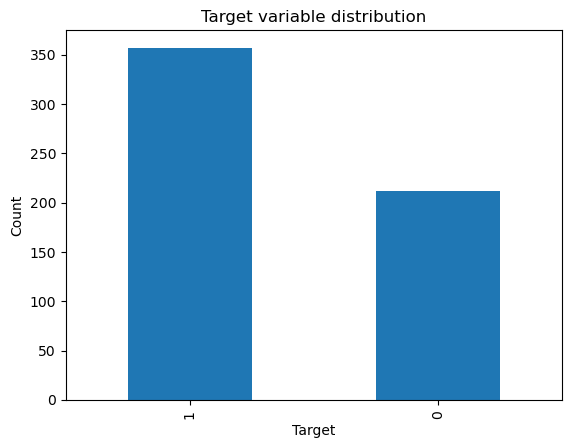

```python
import matplotlib.pyplot as plt
df_target['target'].value_counts().plot(kind='bar')
plt.title('Target variable distribution')
plt.xlabel('Target')
plt.ylabel('Count')
plt.show()
```

```python
df.describe()
```

|  | mean radius | mean texture | mean perimeter | mean area | mean smoothness | mean compactness | mean concavity | mean concave points | mean symmetry | mean fractal dimension | ... | worst radius | worst texture | worst perimeter | worst area | worst smoothness | worst compactness | worst concavity | worst concave points | worst symmetry | worst fractal dimension |
| --- | --- | --- | --- | --- | --- | --- | --- | --- | --- | --- | --- | --- | --- | --- | --- | --- | --- | --- | --- | --- | --- |
| count | 569.000000 | 569.000000 | 569.000000 | 569.000000 | 569.000000 | 569.000000 | 569.000000 | 569.000000 | 569.000000 | 569.000000 | ... | 569.000000 | 569.000000 | 569.000000 | 569.000000 | 569.000000 | 569.000000 | 569.000000 | 569.000000 | 569.000000 | 569.000000 |
| mean | 14.127292 | 19.289649 | 91.969033 | 654.889104 | 0.096360 | 0.104341 | 0.088799 | 0.048919 | 0.181162 | 0.062798 | ... | 16.269190 | 25.677223 | 107.261213 | 880.583128 | 0.132369 | 0.254265 | 0.272188 | 0.114606 | 0.290076 | 0.083946 |
| std | 3.524049 | 4.301036 | 24.298981 | 351.914129 | 0.014064 | 0.052813 | 0.079720 | 0.038803 | 0.027414 | 0.007060 | ... | 4.833242 | 6.146258 | 33.602542 | 569.356993 | 0.022832 | 0.157336 | 0.208624 | 0.065732 | 0.061867 | 0.018061 |
| min | 6.981000 | 9.710000 | 43.790000 | 143.500000 | 0.052630 | 0.019380 | 0.000000 | 0.000000 | 0.106000 | 0.049960 | ... | 7.930000 | 12.020000 | 50.410000 | 185.200000 | 0.071170 | 0.027290 | 0.000000 | 0.000000 | 0.156500 | 0.055040 |
| 25% | 11.700000 | 16.170000 | 75.170000 | 420.300000 | 0.086370 | 0.064920 | 0.029560 | 0.020310 | 0.161900 | 0.057700 | ... | 13.010000 | 21.080000 | 84.110000 | 515.300000 | 0.116600 | 0.147200 | 0.114500 | 0.064930 | 0.250400 | 0.071460 |
| 50% | 13.370000 | 18.840000 | 86.240000 | 551.100000 | 0.095870 | 0.092630 | 0.061540 | 0.033500 | 0.179200 | 0.061540 | ... | 14.970000 | 25.410000 | 97.660000 | 686.500000 | 0.131300 | 0.211900 | 0.226700 | 0.099930 | 0.282200 | 0.080040 |
| 75% | 15.780000 | 21.800000 | 104.100000 | 782.700000 | 0.105300 | 0.130400 | 0.130700 | 0.074000 | 0.195700 | 0.066120 | ... | 18.790000 | 29.720000 | 125.400000 | 1084.000000 | 0.146000 | 0.339100 | 0.382900 | 0.161400 | 0.317900 | 0.092080 |
| max | 28.110000 | 39.280000 | 188.500000 | 2501.000000 | 0.163400 | 0.345400 | 0.426800 | 0.201200 | 0.304000 | 0.097440 | ... | 36.040000 | 49.540000 | 251.200000 | 4254.000000 | 0.222600 | 1.058000 | 1.252000 | 0.291000 | 0.663800 | 0.207500 |

8 rows × 30 columns

With the describe we can see that none of the features are normalize. None of the means is 0, and none of the standard deviations are close to 1.  
To normalize the dataset we can use the StandardScaler function.

```python
from sklearn.preprocessing import StandardScaler

scaler = StandardScaler()
scaler.fit(df)
scaled_data = scaler.transform(df)
df_scaled = pd.DataFrame(scaled_data, columns=data.feature_names)

df_scaled.describe()
```

|  | mean radius | mean texture | mean perimeter | mean area | mean smoothness | mean compactness | mean concavity | mean concave points | mean symmetry | mean fractal dimension | ... | worst radius | worst texture | worst perimeter | worst area | worst smoothness | worst compactness | worst concavity | worst concave points | worst symmetry | worst fractal dimension |
| --- | --- | --- | --- | --- | --- | --- | --- | --- | --- | --- | --- | --- | --- | --- | --- | --- | --- | --- | --- | --- | --- |
| count | 5.690000e+02 | 5.690000e+02 | 5.690000e+02 | 5.690000e+02 | 5.690000e+02 | 5.690000e+02 | 5.690000e+02 | 5.690000e+02 | 5.690000e+02 | 5.690000e+02 | ... | 5.690000e+02 | 5.690000e+02 | 5.690000e+02 | 5.690000e+02 | 5.690000e+02 | 5.690000e+02 | 5.690000e+02 | 5.690000e+02 | 5.690000e+02 | 5.690000e+02 |
| mean | -3.153111e-15 | -6.568462e-15 | -6.993039e-16 | -8.553985e-16 | 6.081447e-15 | -1.136369e-15 | -2.997017e-16 | 1.023981e-15 | -1.860648e-15 | -1.504752e-15 | ... | -2.297713e-15 | 1.742016e-15 | -1.198807e-15 | 6.118909e-16 | -5.094929e-15 | -2.122887e-15 | 6.118909e-16 | -1.998011e-16 | -2.422589e-15 | 2.497514e-15 |
| std | 1.000880e+00 | 1.000880e+00 | 1.000880e+00 | 1.000880e+00 | 1.000880e+00 | 1.000880e+00 | 1.000880e+00 | 1.000880e+00 | 1.000880e+00 | 1.000880e+00 | ... | 1.000880e+00 | 1.000880e+00 | 1.000880e+00 | 1.000880e+00 | 1.000880e+00 | 1.000880e+00 | 1.000880e+00 | 1.000880e+00 | 1.000880e+00 | 1.000880e+00 |
| min | -2.029648e+00 | -2.229249e+00 | -1.984504e+00 | -1.454443e+00 | -3.112085e+00 | -1.610136e+00 | -1.114873e+00 | -1.261820e+00 | -2.744117e+00 | -1.819865e+00 | ... | -1.726901e+00 | -2.223994e+00 | -1.693361e+00 | -1.222423e+00 | -2.682695e+00 | -1.443878e+00 | -1.305831e+00 | -1.745063e+00 | -2.160960e+00 | -1.601839e+00 |
| 25% | -6.893853e-01 | -7.259631e-01 | -6.919555e-01 | -6.671955e-01 | -7.109628e-01 | -7.470860e-01 | -7.437479e-01 | -7.379438e-01 | -7.032397e-01 | -7.226392e-01 | ... | -6.749213e-01 | -7.486293e-01 | -6.895783e-01 | -6.421359e-01 | -6.912304e-01 | -6.810833e-01 | -7.565142e-01 | -7.563999e-01 | -6.418637e-01 | -6.919118e-01 |
| 50% | -2.150816e-01 | -1.046362e-01 | -2.359800e-01 | -2.951869e-01 | -3.489108e-02 | -2.219405e-01 | -3.422399e-01 | -3.977212e-01 | -7.162650e-02 | -1.782793e-01 | ... | -2.690395e-01 | -4.351564e-02 | -2.859802e-01 | -3.411812e-01 | -4.684277e-02 | -2.695009e-01 | -2.182321e-01 | -2.234689e-01 | -1.274095e-01 | -2.164441e-01 |
| 75% | 4.693926e-01 | 5.841756e-01 | 4.996769e-01 | 3.635073e-01 | 6.361990e-01 | 4.938569e-01 | 5.260619e-01 | 6.469351e-01 | 5.307792e-01 | 4.709834e-01 | ... | 5.220158e-01 | 6.583411e-01 | 5.402790e-01 | 3.575891e-01 | 5.975448e-01 | 5.396688e-01 | 5.311411e-01 | 7.125100e-01 | 4.501382e-01 | 4.507624e-01 |
| max | 3.971288e+00 | 4.651889e+00 | 3.976130e+00 | 5.250529e+00 | 4.770911e+00 | 4.568425e+00 | 4.243589e+00 | 3.927930e+00 | 4.484751e+00 | 4.910919e+00 | ... | 4.094189e+00 | 3.885905e+00 | 4.287337e+00 | 5.930172e+00 | 3.955374e+00 | 5.112877e+00 | 4.700669e+00 | 2.685877e+00 | 6.046041e+00 | 6.846856e+00 |

8 rows × 30 columns

### Part 2: Decision Trees

**Train a Decision Tree Model**

```python
from sklearn.model_selection import train_test_split

X_train, X_test, y_train, y_test = train_test_split(df_scaled, df_target, test_size=0.2, random_state=42)
```

```python
from sklearn.tree import DecisionTreeClassifier

clf = DecisionTreeClassifier(criterion='gini')

clf = clf.fit(X_train,y_train)

y_pred = clf.predict(X_test)
```

[Source](https://www.datacamp.com/tutorial/decision-tree-classification-python?dc_referrer=https%3A%2F%2Fwww.ecosia.org%2F)

**Evaluation**

```python
from sklearn.metrics import classification_report
print('Classification Report (Decision Tree Model):\n',
      classification_report(y_test, y_pred))
```

```
Classification Report (Decision Tree Model):
               precision    recall  f1-score   support

           0       0.91      0.91      0.91        43
           1       0.94      0.94      0.94        71

    accuracy                           0.93       114
   macro avg       0.93      0.93      0.93       114
weighted avg       0.93      0.93      0.93       114
```

```python
pip install graphviz
```

```python
import graphviz
from sklearn import tree
# DOT data
dot_data = tree.export_graphviz(clf, out_file=None,
                                feature_names=data.feature_names,
                                class_names=data.target_names,
                                filled=True)

# Draw graph
graph = graphviz.Source(dot_data, format="png")
graph
```

[figure not shown]

[Source](https://mljar.com/blog/visualize-decision-tree/)

**Hyperparameter Tuning**

```python
import time
import numpy as np
from sklearn.model_selection import GridSearchCV
# setup parameter space
parameters = {'criterion':['gini','entropy'],
              'max_depth':np.arange(1,21).tolist()[0::2],
              'min_samples_split':np.arange(2,11).tolist()[0::2],
              'max_leaf_nodes':np.arange(3,26).tolist()[0::2]}

# create an instance of the grid search object
g1 = GridSearchCV(DecisionTreeClassifier(), parameters, cv=5, n_jobs=-1)

# conduct grid search over the parameter space
start_time = time.time()
g1.fit(X_train,y_train)
duration = time.time() - start_time

# show best parameter configuration found for classifier
cls_params1 = g1.best_params_
cls_params1
```

```
{'criterion': 'entropy',
 'max_depth': 5,
 'max_leaf_nodes': 13,
 'min_samples_split': 6}
```

[Source](https://insidelearningmachines.com/tune_hyperparameters_in_decision_trees/)

```python
clf_best = DecisionTreeClassifier(criterion='entropy', max_depth=5, max_leaf_nodes=13, min_samples_split=6)
clf_best = clf_best.fit(X_train,y_train)
y_pred_best = clf_best.predict(X_test)

print('Classification Report (Decision Tree Model):\n', classification_report(y_test, y_pred_best))
```

```
Classification Report (Decision Tree Model):
               precision    recall  f1-score   support

           0       0.97      0.91      0.94        43
           1       0.95      0.99      0.97        71

    accuracy                           0.96       114
   macro avg       0.96      0.95      0.95       114
weighted avg       0.96      0.96      0.96       114
```

Indeed we see that with those parameter the result are better. The accuracy is now of 96% instead of 93%, and both of the f1-score improved.

### Part 3: Random Forest

**Train a Random Forest Model**

```python
from sklearn.ensemble import RandomForestClassifier
rf = RandomForestClassifier() # default : n_estimators=100
rf.fit(X_train, y_train)
y_pred_rf = rf.predict(X_test)

print('Classification Report (Random forest Model):\n', classification_report(y_test, y_pred_rf))
```

```
Classification Report (Random forest Model):
               precision    recall  f1-score   support

           0       0.98      0.93      0.95        43
           1       0.96      0.99      0.97        71

    accuracy                           0.96       114
   macro avg       0.97      0.96      0.96       114
weighted avg       0.97      0.96      0.96       114
```

[Source](https://www.datacamp.com/tutorial/random-forests-classifier-python)

```python
rf_10 = RandomForestClassifier(n_estimators=10)
rf_10.fit(X_train, y_train)
y_pred_rf_10 = rf_10.predict(X_test)

print('Classification Report (Random forest Model):\n', classification_report(y_test, y_pred_rf_10))
```

```
Classification Report (Random forest Model):
               precision    recall  f1-score   support

           0       0.98      0.93      0.95        43
           1       0.96      0.99      0.97        71

    accuracy                           0.96       114
   macro avg       0.97      0.96      0.96       114
weighted avg       0.97      0.96      0.96       114
```

```python
rf_200 = RandomForestClassifier(n_estimators=200)
rf_200.fit(X_train, y_train)
y_pred_rf_200 = rf_200.predict(X_test)

print('Classification Report (Random forest Model):\n', classification_report(y_test, y_pred_rf_200))
```

```
Classification Report (Random forest Model):
               precision    recall  f1-score   support

           0       0.98      0.93      0.95        43
           1       0.96      0.99      0.97        71

    accuracy                           0.96       114
   macro avg       0.97      0.96      0.96       114
weighted avg       0.97      0.96      0.96       114
```

Previously (with past split): We could see that with 10 estimators, the f1-score of Malignant is larger, but that's about it for the difference. As for between 100 and 200 estimator, nothing changes.  
With this split nothing has really changed between 10, 100 or 200 estimators.

**Feature Importance**

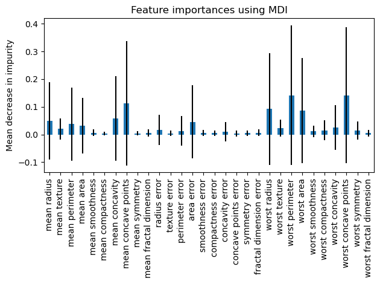

```python
importances = rf.feature_importances_
feature_names = df.columns  # Utiliser les noms des colonnes du DataFrame
std = np.std([tree.feature_importances_ for tree in rf.estimators_], axis=0)

forest_importances = pd.Series(importances, index=feature_names)

fig, ax = plt.subplots()
forest_importances.plot.bar(yerr=std, ax=ax)
ax.set_title("Feature importances using MDI")
ax.set_ylabel("Mean decrease in impurity")
fig.tight_layout()
plt.show()
```

[Source](https://scikit-learn.org/dev/auto_examples/ensemble/plot_forest_importances.html)

**Model Performance**

We can see that the model of random forest is better than decision tree model. Example: f1-score of 0 : 95% vs. 94%, precision of 1 : 96% vs. 95%...

```python
n_estimators = [2, 10, 50, 100, 200, 500, 5000]
accuracies_oob = []

for n in n_estimators:
    rf = RandomForestClassifier(n_estimators=n, oob_score=True, random_state=42)
    rf.fit(X_train, y_train)
    accuracy = rf.oob_score_
    accuracies_oob.append((n, accuracy))

for n, accuracy in accuracies_oob:
    print(f"Nb of estimators: {n}, OOB score: {accuracy:.4f}")
```

```
Nb of estimators: 2, OOB score: 0.6879
Nb of estimators: 10, OOB score: 0.9407
Nb of estimators: 50, OOB score: 0.9429
Nb of estimators: 100, OOB score: 0.9560
Nb of estimators: 200, OOB score: 0.9604
Nb of estimators: 500, OOB score: 0.9626
Nb of estimators: 5000, OOB score: 0.9648
```

### Part 4: Feature Importance Analysis

**Feature Importance in Decision Trees**

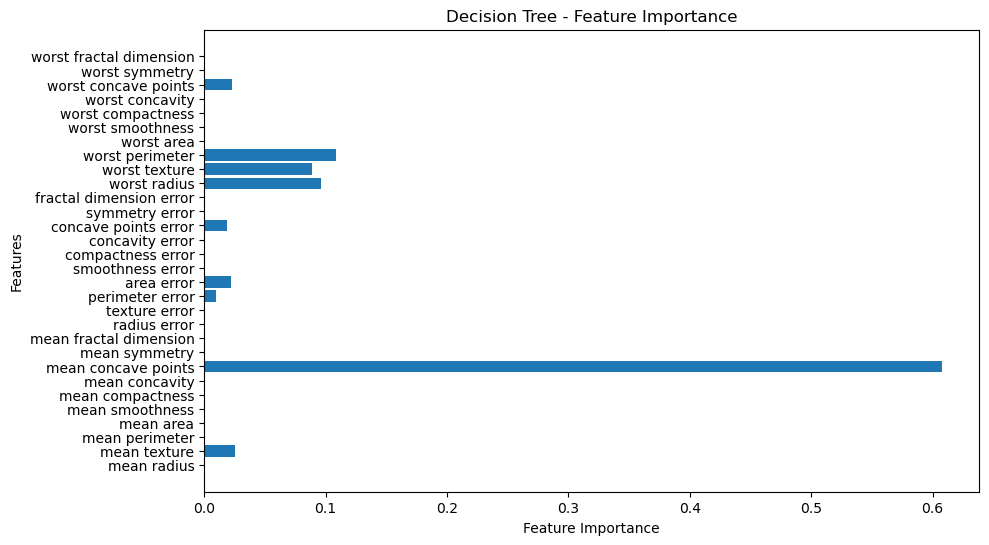

```python
feature_importance = clf_best.feature_importances_
features = data.feature_names

plt.figure(figsize=(10, 6))
plt.barh(np.arange(len(features)), feature_importance, align='center')
plt.yticks(np.arange(len(features)), features)
plt.xlabel("Feature Importance")
plt.ylabel("Features")
plt.title("Decision Tree - Feature Importance")
plt.show()
```

***Which features are most important for decision trees?***  
The most important features for decision trees is 'Mean concave points' from a lot.

***Do the most important features align with breast cancer knowledge?***  
at first glance yes, because 'Mean concave points' tend to be important to detect malignant tumors.

**Feature Importance in Random Forests**

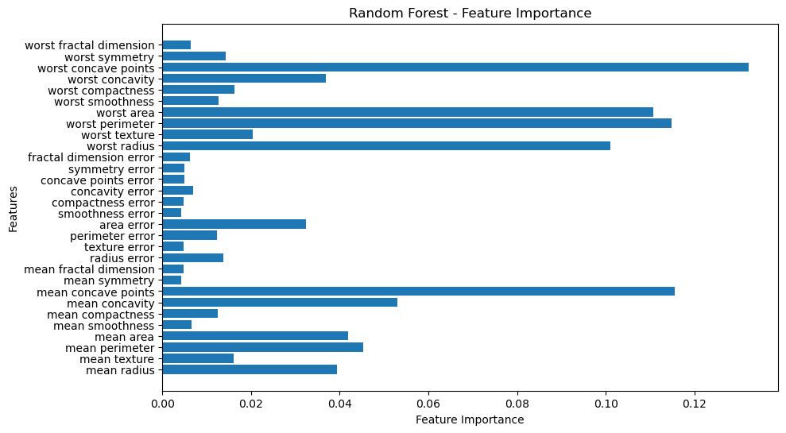

```python
rf_feature_importance = rf.feature_importances_
plt.figure(figsize=(10, 6))
plt.barh(np.arange(len(features)), rf_feature_importance, align='center')
plt.yticks(np.arange(len(features)), features)
plt.xlabel("Feature Importance")
plt.ylabel("Features")
plt.title("Random Forest - Feature Importance")
plt.show()
```

***Are the same features important in both decision trees and random forests?***  
'Mean concave points' is important for both decision trees and random forests.

***Which features are consistently ranked as highly important?***  
'Mean concave points' is consistently ranked as highly important. We also could say 'Worst perimeter'.

### Part 5: Questions for Analysis

**Decision Trees**

```python
from sklearn.metrics import accuracy_score
accuracy_default = accuracy_score(y_test, y_pred_best)
print(f"Accuracy: {accuracy_default:.4f}")
```

```
Accuracy: 0.9561
```

```python
y_pred_train_best = clf_best.predict(X_train)
accuracy_default = accuracy_score(y_train, y_pred_train_best)
print(f"Accuracy: {accuracy_default:.4f}")
```

```
Accuracy: 0.9890
```

***What is the accuracy of the decision tree model on the testing set? How does it compare to the training set? Does the model overfit or underfit the data?***  
The accuracy of the best decision tree model on the testing set is 96%. When you use the model on the training set you have a accuracy of 99%, witch is completly normal because the model was train on that set. Because the accuracy on the training sset is so high (almost 100%), the model might overfit that set.

```python
clf = DecisionTreeClassifier(max_depth=2)
clf = clf.fit(X_train,y_train)
y_pred = clf.predict(X_test)

accuracy_default = accuracy_score(y_test, y_pred)
print(f"Accuracy: {accuracy_default:.4f}")
```

```
Accuracy: 0.9298
```

```python
clf = DecisionTreeClassifier(max_depth=8)
clf = clf.fit(X_train,y_train)
y_pred = clf.predict(X_test)

accuracy_default = accuracy_score(y_test, y_pred)
print(f"Accuracy: {accuracy_default:.4f}")
```

```
Accuracy: 0.9474
```

```python
clf = DecisionTreeClassifier(max_depth=32)
clf = clf.fit(X_train,y_train)
y_pred = clf.predict(X_test)

accuracy_default = accuracy_score(y_test, y_pred)
print(f"Accuracy: {accuracy_default:.4f}")
```

```
Accuracy: 0.9474
```

```python
clf = DecisionTreeClassifier(criterion='gini')
clf = clf.fit(X_train,y_train)
y_pred = clf.predict(X_test)

accuracy_default = accuracy_score(y_test, y_pred)
print(f"Accuracy: {accuracy_default:.4f}")
```

```
Accuracy: 0.9386
```

```python
clf = DecisionTreeClassifier(criterion='entropy')
clf = clf.fit(X_train,y_train)
y_pred = clf.predict(X_test)

accuracy_default = accuracy_score(y_test, y_pred)
print(f"Accuracy: {accuracy_default:.4f}")
```

```
Accuracy: 0.9386
```

***What criteria (Gini or Entropy) performed better? Why do you think that is the case?***  
From that test, the criteria performed the same. However, in the part 2 for the *hyperparameter tuning* we saw that entropy performed better. Entropy might be better because it tends to do more calculate and precise slip than Gini.

```python
dot_data = tree.export_graphviz(clf_best, out_file=None,
                                feature_names=data.feature_names,
                                class_names=data.target_names,
                                filled=True)

# Draw graph
graph = graphviz.Source(dot_data, format="png")
graph
```

[figure not shown]

***Visualize the decision tree. Are there any features that are consistently used at higher levels of the tree (closer to the root)?***  
Like we saw before the most important feature are: 'Mean concave point', 'Worst Perimeter' and 'Worst Radius'.

**Random Forest**

***How does the accuracy of the random forest model compare to the decision tree? Which model generalizes better to unseen data?***  
We can see that the model of random forest is better than decision tree model.  
Example: f1-score for 0 : **95%** VS **94%**, f1-score 1 : **97%** vs **97%**...  
The Random Forest model seems to generalize better to unseen data, offering a more balanced performance across both classes.

***Analyze the feature importance scores from the random forest. Which features are most important for predicting breast cancer? Do they align with domain knowledge or medical understanding?***  
`Mean concave points`, `Worst concave points` and `worst perimeter` are important in the random forests model.

`Mean concave points`: Malignant tumors often have more irregular contours with marked concavities, which differentiates them from benign tumors according to our research.

`Worst concave points` : Malignant tumors are known to have more irregular shapes compared to benign tumors, often characterized by more pronounced concavities in their structure. These concavities are formed due to the uncontrolled and aggressive growth of cancerous cells. Tumors with many or deep concave points are more likely to be malignant because benign tumors tend to have smoother, more regular shapes.

`Worst perimeter`: Malignant tumors generally have cells with larger and more irregular contours compared to benign tumors.

***What are the advantages of using a random forest over a single decision tree? Discuss concepts like variance reduction and robustness to overfitting.***  
Random Forests are preferred over single decision trees for their variance reduction and robustness to overfitting. By averaging the predictions from multiple trees, they stabilize the model, handle noisy data better, and offer improved generalization to unseen data. This ensemble approach mitigates the key weaknesses of a single decision tree, making Random Forests a more reliable and powerful model for most tasks.

**General Comparison**

```python
y_pred = clf.predict(X_test)
accuracy_default = accuracy_score(y_test, y_pred)
print(f"Accuracy: {accuracy_default:.4f}")
```

```
Accuracy: 0.9386
```

```python
y_pred_rf = rf.predict(X_test)
accuracy_default = accuracy_score(y_test, y_pred)
print(f"Accuracy: {accuracy_default:.4f}")
```

```
Accuracy: 0.9386
```

***Discuss the trade-offs between model interpretability (decision trees) and accuracy (random forests).***  
For the decision tree, the model is way more understandable because we can see a clear structure. However, those models tend to overfit the training set (as seen in this part 5 'Decision Trees').  
For the random forest, those models have a better accuracy, but it's almost impossible to understand how the model works, because of the many decision tree used.

***How could you further improve the performance of these models? Would using techniques like bagging, boosting, or more advanced models (e.g., gradient boosting) make a difference?***

- Bagging can help reduce overfitting.
- Boosting can improve accuracy.
- Advanced models like Gradient Boosting Machines could improve the model significantly, but it would increase a lot the complexity of the model.

**Conclusion and Discussion**

***Your are ncouraged to reflect on the importance of hyperparameter tuning, model evaluation, and the concept of bias-variance tradeoff***

***Optionally, you can apply cross-validation to further validate the stability of your models.***

```python
from sklearn.model_selection import cross_val_score
clf_best = DecisionTreeClassifier(criterion='entropy', max_depth=5, max_leaf_nodes=25, min_samples_split=2)
cv_scores_dt = cross_val_score(clf_best, df_scaled, df_target, cv=5, scoring='accuracy')
print(f'Decision Tree 5-Fold Cross-Validation Accuracy: {cv_scores_dt}')
print(f'Decision Tree Mean CV Accuracy: {cv_scores_dt.mean():.4f}')

rf_model = RandomForestClassifier(n_estimators=100, random_state=42)
cv_scores_rf = cross_val_score(rf_model, df_scaled, df_target, cv=5, scoring='accuracy')
print(f'Random Forest 5-Fold Cross-Validation Accuracy: {cv_scores_rf}')
print(f'Random Forest Mean CV Accuracy: {cv_scores_rf.mean():.4f}')
```

```
Decision Tree 5-Fold Cross-Validation Accuracy: [0.89473684 0.90350877 0.94736842 0.95614035 0.94690265]
Decision Tree Mean CV Accuracy: 0.9297
```

```
Random Forest 5-Fold Cross-Validation Accuracy: [0.92105263 0.93859649 0.98245614 0.96491228 0.97345133]
Random Forest Mean CV Accuracy: 0.9561
```